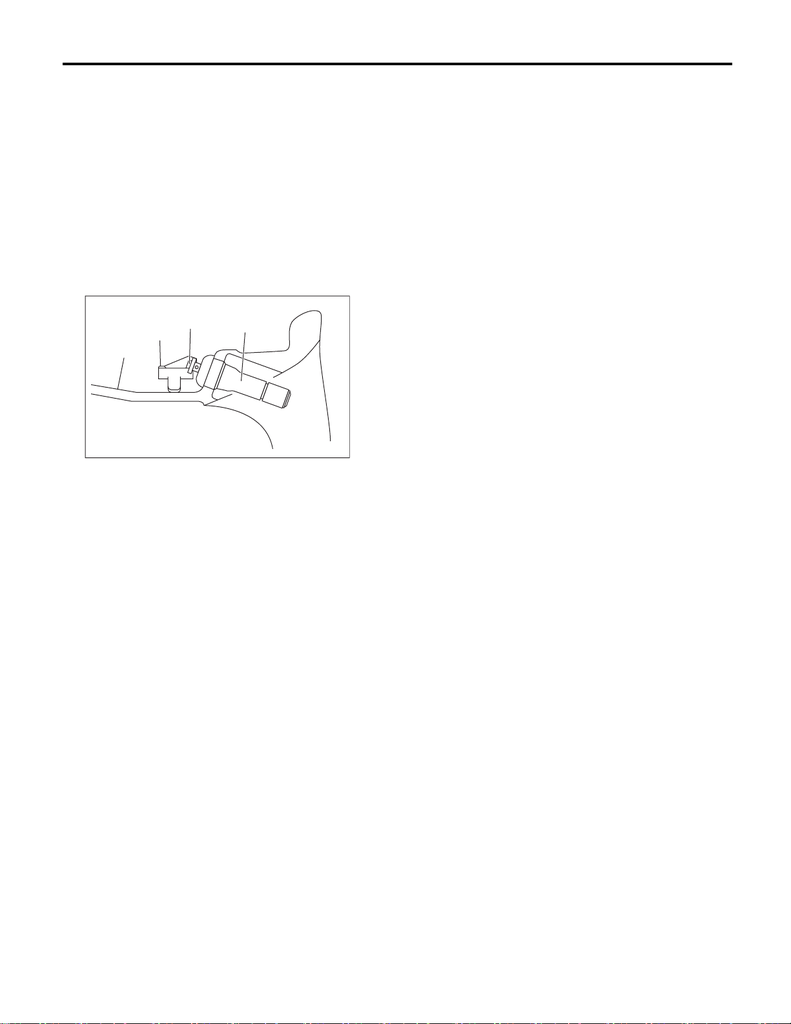

WT-9

Tire Pressure Monitoring System

WHEEL AND TIRE SYSTEM

4. Tire Pressure Monitoring System

A: REMOVAL

1. TRANSMITTER (TIRE INFLATION PRESSURE SENSOR)

1) Remove the wheels from the vehicle. <Ref. to WT-5, REMOVAL, Tire and Wheel.>

2) Remove the tires from wheels.

CAUTION:

Use a tire changer when removing the tire from the wheel.

3) Loosen the screw to remove the transmitter from the valve stem.

CAUTION:

Do not reuse the valve and screw.

Replace the valve and screw with a new part even when reusing transmitter.

4) Remove the valve from the wheel.

2. TPMS & KEYLESS CONTROL MODULE

NOTE:

TPMS control module for keyless entry model is integrated with the keyless entry control module. For remov-

al procedures, refer to “SECURITY AND LOCKS” section. <Ref. to SL-76, REMOVAL, Keyless Entry Control

Module.>

(1) Wheel

(2) Transmitter

(3) Screw

(4) Valve

WT-00125

(1)

(2)

(4)

(3)

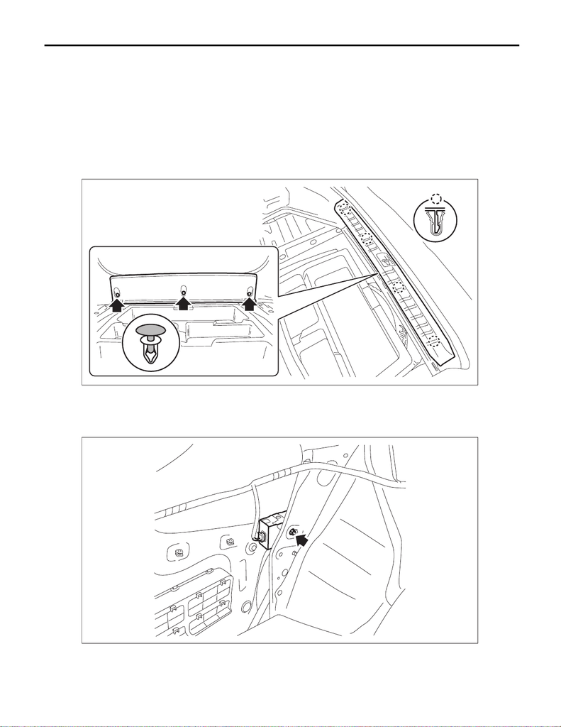

WT-10

Tire Pressure Monitoring System

WHEEL AND TIRE SYSTEM

3. TPMS CM

NOTE:

TPMS control module for keyless access model is separated from the keyless access control module.

1) Disconnect the ground cable from battery. <Ref. to NT-5, BATTERY, NOTE, Note.>

NOTE:

For models other than STI model, disconnect the ground terminal from battery sensor.

2) Remove the trunk room mat.

3) Remove the trim panel - trunk rear.

(1) Remove the clip.

(2) Release the claws, and remove the trim panel - trunk rear.

4) Remove the trim panel - trunk side LH. <Ref. to EI-95, REMOVAL, Trunk Room Trim.>

5) Remove the TPMS CM.

(1) Disconnect the connector.

(2) Remove the nuts to remove the TPMS CM.

EI-04374

WT-00209

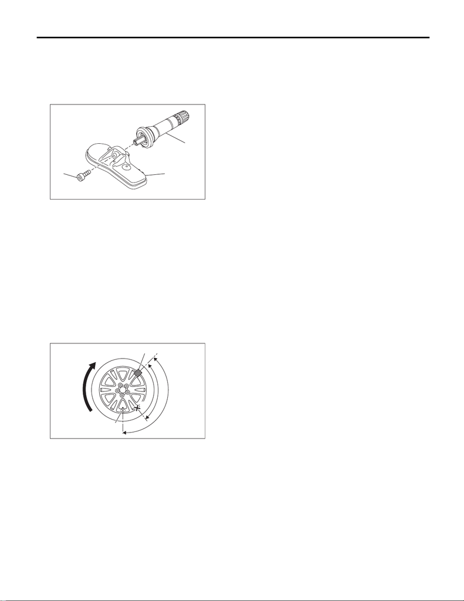

WT-11

Tire Pressure Monitoring System

WHEEL AND TIRE SYSTEM

B: INSTALLATION

1. TRANSMITTER (TIRE INFLATION PRESSURE SENSOR)

CAUTION:

Use the new transmitter assembly or replace the new valve and screw, when installing.

1) Replace the valve and screw with a new part when reusing transmitter.

Tightening torque:

1.4 N·m (0.1 kgf-m, 1.0 ft-lb)

2) Install the transmitter to the wheel by aligning it with valve hole.

NOTE:

When using the jig that pulls the valve cap by hooking its neck part, use another short-type cap.

3) Install the tires to wheels.

CAUTION:

• Use a tire changer when installing tire to wheel.

• To prevent damaging the transmitter, set the tire changer boom in the position as shown in the fig-

ure.

4) Install the wheels to vehicle. <Ref. to WT-5, INSTALLATION, Tire and Wheel.>

5) Register the transmitter ID to the TPMS & keyless control module. <Ref. to TPM(diag)-14, Register Trans-

mitter (ID).>

(1) Screw

(2) Transmitter

(3) Valve

WT-00205

(2)

(1)

(3)

(1) Transmitter

(2) Direction of turn table rotation

(3) 135°

(4) Tire changer boom

(5) 90°

(6) Starting point for fitting the bead to the rim

(1)

(6)

(5)

(3)

(4)

(2)

WT-00130

[figure not shown]

WT-12

Tire Pressure Monitoring System

WHEEL AND TIRE SYSTEM

2. TPMS & KEYLESS CONTROL MODULE

NOTE:

TPMS control module for keyless entry model is integrated with the keyless entry control module. For instal-

lation procedures, refer to “SECURITY AND LOCKS” section. <Ref. to SL-76, INSTALLATION, Keyless En-

try Control Module.>

3. TPMS CM

NOTE:

TPMS control module for keyless access model is separated from the keyless access control module.

1) Install the TPMS CM.

Tightening torque:

7.5 N·m (0.8 kgf-m, 5.5 ft-lb)

2) Install the trim panel - trunk side LH.

3) Install the trim panel - trunk rear.

4) Connect the battery ground terminal. <Ref. to NT-5, BATTERY, NOTE, Note.>

NOTE:

For models other than STI model, connect the ground terminal to battery sensor.

C: ADJUSTMENT

Re-register the transmitter ID when transmitter has been replaced. <Ref. to TPM(diag)-14, Register Trans-

mitter (ID).>